# Notebook for Data Analyses of Chinese Samples in Psychological Subjects [Stage 1 RR]

Lei Yue (NNU, CCNU); Hu Chuan-Peng (NNU; hcp4715@hotmail.com)

This is an [R Markdown](http://rmarkdown.rstudio.com) file for data analyses in the protocol of a meta research which aims at surveying sample characteristics of Chinese sample in Chinese Psychological research.

In this script, we will use data from PSA 001 project [Jones et al., 2021, *Nature Human Behavior*](https://doi.org/10.1038/s41562-020-01007-2) to exemplify the analyses that we are going to use in our this project.

First, load libraries.

```r
library(tidyverse)
library(ggridges)
library(openxlsx)
library(ggh4x)
library(stringr)
library(patchwork)
rm(list = ls())
```

### Define Bayesian multinomial test

This function is defined as in [JASP](https://github.com/jasp-stats/jaspFrequencies/blob/d48babf63b14526abaf2c208c8ae769801b6d4db/R/multinomialtestbayesian.R#L384).

#### Probability mass function (PMF)

The PMF of multinomial distribution is:

$$f(x_1, ..., x_k; n, p_1, ..., p_n) =
Pr(X_1 = x_1 and ... and X_k = x_k) = \frac{n!}{x_1! ... x_n!} p_1^{x_1}
\times ... \times p_k^{x_k}$$
, when $\sum_{i=1}^{k}{x_i=n}$, for non-negative integers $x_1, ..., x_k$.

This PMF can be expressed using the gamma function as:

$$f(x_1, ..., x_k; n, p_1, ..., p_n) =
\frac{\Gamma(\sum_{i}{x_i +1})}{\prod_{i}\Gamma(x_i + 1)}
\prod_{i=1}^{k} p_{i}^{x_i}$$

In $R$, we can directly use the `gamma` and `lgamma` to calculate the PMF. Where `gamma` function is defined as: $\Gamma (x) = \int_{0}^{\infty} t^{(x-1)} \exp(-t)dt$

and the `lgamma` is defined as the log of `gamaa`.

$(x)!$ for non-negative integer x is defined to be $\Gamma (x+1)$

```r
BayesMultiNomial <- function(dataset, factor, observed, expected, default_prior = TRUE, prior = NA){
  # datase - the input dataframe
  # factor - column name of the factor,
  # observed - column name of the column contains counts information for the observed,
  # expected - column name of the column contains counts information for the expected,
  # default_prior - whether use the default, defused prior
  # prior - priors defined by users

  library(tidyverse)

  fact_level <- dataset %>% dplyr::select(all_of(factor)) %>% dplyr::pull() #  %>% as.factor(.)
  observed_data <- dataset %>% dplyr::select(all_of(observed)) %>% dplyr::pull()
  names(observed_data) <- fact_level
  expected_data <- dataset %>% dplyr::select(all_of(expected)) %>% dplyr::pull()
  n_levels <- length(observed_data)

  if (default_prior & is.na(prior)) {
    prior <- rep(1, n_levels)
  } else{
    prior <- prior
  }

  alphas <- prior
  counts <- observed_data
  thetas <- expected_data

  if(sum(thetas) != 1) {
    thetas <- thetas/sum(thetas)
    }

  expected <- setNames(sum(counts)*thetas, names(counts))

  lbeta.xa <- sum(lgamma(alphas + counts)) - lgamma(sum(alphas + counts))
  lbeta.a  <- sum(lgamma(alphas)) - lgamma(sum(alphas))

  if (any(rowSums(cbind(thetas, counts)) == 0)) {
    LogBF10 <- (lbeta.xa-lbeta.a)
  } else {
    LogBF10 <- (lbeta.xa-lbeta.a) + (0 - sum(counts * log(thetas)))
  }

  BF <- data.frame(LogBF10 = LogBF10,
                   BF10    = exp(LogBF10),
                   BF01    = 1/exp(LogBF10))

  return(list(BF       = BF,
              expected = expected))

}
```

Second, load the data and carry out initial preprocessing.

```r
load("df_chinese_subj_rr_stage1.RData")

# check data
# str(df_PSA001) # have an overview of the data
# str(df_CFPS2018)
# str(df_census6)
# str(df_regionCode)
# str(df_census7)
```

## Test the 1st hypothesis

*This can only be done after collecting data.*

## Testing the 2nd hypothesis

Here we will test whether the sex ratio and age distribution from Chinese psychological studies are similar to that of the census data. As a comparison, we also compared that data from sociology, CFPS 2018, to the census data too. We use Bayesian multinomial test (Bayesian goodness-of-fit test) to examine whether the observed (Chinese psychological samples) fit the expected (Census data).

$H_0$: the observed fits the expected distribution; $H_1$: the observed does not fit the expected.

### Sex distribution

```r
df_PSA001_sex_CN <- df_PSA001 %>%
  dplyr::filter(Countries == "CN") %>%
  dplyr::count(Sex) %>%
  dplyr::mutate(Proportion = round(n / sum(n), 2) * 100,
                Site = "PSA001",
                Sex = ifelse(Sex == "f", 'female', 'male' )) %>%
  dplyr::select(Site, Sex, Proportion)

df_census7_sex <- df_census7 %>%
  dplyr::select(c(6,7)) %>%
  dplyr::slice(c(6)) %>%
  dplyr::rename(male=1,
                female=2) %>%
  dplyr::mutate(Site = "Census7") %>%
  tidyr::pivot_longer(c(male, female),
                      names_to = "Sex",
                      values_to = "Proportion") %>%
  dplyr::mutate(Proportion = round(as.numeric(Proportion), 0))

df_CFPS2018_sex <- df_CFPS2018 %>%
  dplyr::rename(Sex = QA002) %>%
  dplyr::count(Sex) %>%
  dplyr::filter(!is.na(Sex)) %>%
  dplyr::mutate(Proportion = round(n / sum(n), 2) * 100,
                Site = "CFPS2018",
                Sex = ifelse(Sex == 1, "male", "female")) %>%
  dplyr::select(Site, Sex, Proportion)

df_sex_ratio <- rbind(df_census7_sex, df_CFPS2018_sex, df_PSA001_sex_CN)

### get the data for Bayesian mutlinomial test as in JASP
df_sex_ratio_jasp <- df_sex_ratio %>%
  tidyr::pivot_wider(names_from = Site,
                     values_from = Proportion)

BF_h2a_sex_psych <- BayesMultiNomial(dataset = df_sex_ratio_jasp, factor = "Sex", observed = "PSA001", expected = "Census7")
BF_h2a_sex_cfps <- BayesMultiNomial(dataset = df_sex_ratio_jasp, factor = "Sex", observed = "CFPS2018", expected = "Census7")

fig3a <- ggplot(df_sex_ratio, aes(Site, Proportion,fill=Sex)) +
  geom_col() +
  theme_classic()+
  xlab("Data sources") +
  theme(legend.position = "bottom",
        legend.key.size = unit(20,"pt"),
        legend.box.spacing = unit(4,"pt"),
        legend.title = element_blank(),
        axis.title = element_text(size = 16, family = "serif"),
        legend.text = element_text(size = 16, family = "serif"),
        axis.text = element_text(size =16, family = "serif"))

# fig3a
```

We found strong evidence for the $H_1$ that the sex ratio from PSA001 is different from that of Census data, with $Log(BF_{10})$ = 3.7333804. On the contrast, for the CFPS data, we found moderate evidence for the $H_0$ that sex ratio from CFPS2018 is not different from that of Census data, $Log(BF_{10})$ = -2.0642401

### Age distribution

Here we will compare the age distribution of samples from psychological studies (PSA 001 as the example) and the Census data.

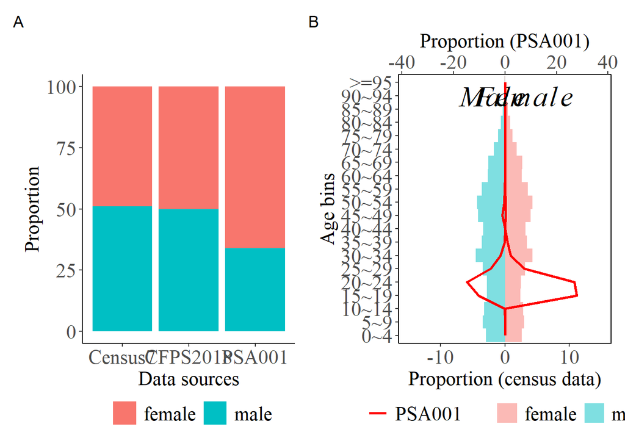

```r
#  <- PSA_Jones_CN
df_PSA001_Age_CN <- df_PSA001 %>%
  dplyr::filter(!is.na(Age)) %>%
  dplyr::filter(Countries == "CN") %>%
  dplyr::mutate(ageBins_pyr = cut(Age,
                                   breaks=c(-Inf, 5, 10, 15, 20, 25, 30, 35, 40, 45,
                                            50, 55,60,65,70, 75,80,85,90,95, Inf),
                            labels=c("0~4","5~9","10~14", "15~19", "20~24", "25~29", "30~34", "35~39", "40~44",
                                     "45~49","50~54","55~59","60~64","65~69","70~74", "75~79",
                                     "80~84","85~89", "90~94",">=95")),
                ageBins_pyr = factor(ageBins_pyr, levels = c("0~4","5~9","10~14", "15~19", "20~24", "25~29",
                                                             "30~34", "35~39", "40~44", "45~49","50~54",
                                                             "55~59","60~64","65~69","70~74", "75~79",
                                                             "80~84","85~89", "90~94",">=95"))) %>%
  dplyr::count(ageBins_pyr, Sex) %>%
  dplyr::mutate(Proportion = round(n / sum(n), 4) * 100) %>%
  tidyr::complete(ageBins_pyr, Sex, fill=list(Proportion=0)) %>%
  dplyr::mutate(Site = "PSA001",
                Sex = ifelse(Sex == "f", "female_PSA", "male_PSA"))


df_census7_age94 <- df_census7 %>%
  dplyr::select(c(1,6,7)) %>%
  dplyr::slice(c(8,15,22,29,36,43,
                 49,56,63,70,77,84,
                 91,98,105,112,119,
                 126,133)) %>%
  dplyr::rename(ageBins=1,
                male=2,
                female=3) %>%
  dplyr::mutate(ageBins = c("0~4","5~9","10~14", "15~19", "20~24",                                    "25~29", "30~34", "35~39", "40~44",     "45~49","50~54","55~59","60~64","65~69","70~74", "75~79",
                                     "80~84","85~89", "90~94"))

###Combining the data of 95 years old and above and controlling the number of the decimal places
df_census7_age95 <- data.frame(ageBins = c(">=95"),
                            male = round((271455 + 35129)/1409778724*100, 2),
                            female = round((548357 + 83737)/1409778724*100, 2))

df_census7_age <- rbind(df_census7_age94, df_census7_age95) %>%
  dplyr::mutate(ageBins = factor(ageBins, levels = c("0~4","5~9","10~14", "15~19", "20~24", "25~29", "30~34",
                                                     "35~39", "40~44","45~49","50~54","55~59","60~64","65~69",
                                                     "70~74", "75~79", "80~84","85~89", "90~94",">=95"))) %>%
  tidyr::pivot_longer(-ageBins, names_to = "Sex", values_to = "Proportion") %>%
  dplyr::mutate(Proportion=as.numeric(Proportion))


### Plotting
fig3b <- ggplot(data= df_census7_age, aes(x=ageBins, y=ifelse(Sex=="male", -Proportion, Proportion), fill=Sex)) +
  geom_col(alpha=0.5, width = 1) +
  geom_line(data = df_PSA001_Age_CN, aes(x=ageBins_pyr,
                                      y = ifelse(Sex == "male_PSA", -Proportion/2.5, Proportion/2.5),
                                      group=Sex,color="PSA001"), size=1, inherit.aes = FALSE) +
  scale_y_continuous(limits = c(-15,15),sec.axis = sec_axis(~.*2.5, name = "Proportion (PSA001)")) +
  coord_flip() +
  labs(y="Proportion (census data)", x = "Age bins", color=NULL)+
  annotate("text",label= "italic(Male)",x=19,y=-2,parse=TRUE,size=8, family = "serif") +
  annotate("text",label= "italic(Female)",x=19,y=3,parse=TRUE,size=8,family = "serif") +
  scale_color_manual(values = c("red","blue"))+
  theme_classic()+
  theme(panel.border =element_rect(fill=NA,color="black"),
        legend.position ="bottom",
        legend.box.spacing = unit(2,"pt"),
        legend.text = element_text(size = 16, family = "serif"),
        legend.title = element_blank(),
        axis.title = element_text(size = 16,family = "serif"),
        axis.text = element_text(size = 16,family = "serif"))

fig3 <- fig3a + fig3b +  plot_annotation(tag_levels = 'A')
ggsave("fig3.pdf", fig3, device = "pdf", width=16, height = 9)

fig3
```

Also get the data for Bayesian multinomial test

```r
df_PSA001_Age_CN_Jasp <- df_PSA001 %>%
  dplyr::filter(!is.na(Age)) %>%
  dplyr::filter(Countries == "CN") %>%
  dplyr::filter(!is.na(Age)) %>%
  dplyr::select(user_id, Countries, Sex, Age) %>%
  dplyr::mutate(ageBins=cut(Age,
                            breaks=c(0, 9.5, 19.5, 29.5, 30.5, 40.5, 59.5, Inf),
                            labels=c("0~9","10~19","20~29", "30~39", "40~49", "50~59", ">=60"))) %>%
  dplyr::count(Countries, ageBins) %>%
  dplyr::group_by(Countries) %>%
  dplyr::mutate(freq = (n / sum(n))*100) %>%
  dplyr::ungroup() %>%
  tidyr::complete(Countries, ageBins, fill = list(n = 0, freq = 0)) %>%
  dplyr::mutate(percent = floor(freq),
                indx = freq - percent) %>%
  dplyr::arrange(desc(indx))

if (sum(df_PSA001_Age_CN_Jasp$percent) < 100) {
    for (jj in seq(100 - sum(df_PSA001_Age_CN_Jasp$percent))){
     df_PSA001_Age_CN_Jasp$percent[jj] <- df_PSA001_Age_CN_Jasp$percent[jj] + 1
    }
}

df_PSA001_Age_CN_Jasp <- df_PSA001_Age_CN_Jasp %>%
  dplyr::select(ageBins, percent) %>%
  dplyr::rename(PSA001_CN = percent)

df_census7_age_jasp <- df_census7_age %>%
  tidyr::pivot_wider(names_from = "Sex", values_from = "Proportion") %>%
  dplyr::mutate(newAge = case_when(ageBins=="0~4" ~ "0~9",   ageBins == "5~9"   ~ "0~9",
                                   ageBins=="10~14"~"10~19", ageBins=="15~19"~"10~19",
                                   ageBins=="20~24" ~ "20~29", ageBins=="25~29" ~ "20~29",
                                   ageBins=="30~34" ~ "30~39", ageBins=="35~39" ~ "30~39",
                                   ageBins=="40~44" ~ "40~49", ageBins=="45~49" ~ "40~49",
                                   ageBins=="50~54" ~ "50~59", ageBins=="55~59" ~ "50~59",
                                   ageBins=="60~64" ~ ">=60" , ageBins=="65~69" ~ ">=60",
                                   ageBins=="70~74" ~ ">=60",  ageBins=="75~79" ~ ">=60",
                                   ageBins=="80~84" ~ ">=60",  ageBins=="85~89" ~ ">=60",
                                   ageBins=="90~94" ~ ">=60",  ageBins==">=95" ~ ">=60")) %>%
  dplyr::group_by(newAge) %>%
  dplyr::summarise(newFemale = sum(female),
                   newMale = sum(male)) %>%
  dplyr::ungroup() %>%
  dplyr::mutate(Prop = newFemale + newMale) %>%
  dplyr::mutate(percent = floor(Prop),
                indx = Prop - percent) %>%
  dplyr::arrange(desc(indx))

if (sum(df_census7_age_jasp$percent) < 100) {
    for (jj in seq(100 - sum(df_census7_age_jasp$percent))){
     df_census7_age_jasp$percent[jj] <- df_census7_age_jasp$percent[jj] + 1
    }
  }

df_census7_age_jasp <- df_census7_age_jasp %>%
  dplyr::rename(Census7 = percent,
                ageBins = newAge) %>%
  dplyr::select(ageBins, Census7)

df_PSA001_Age_CN_Jasp_new <- df_PSA001_Age_CN_Jasp %>%
  dplyr::left_join(., df_census7_age_jasp) %>%
  dplyr::mutate(ageBins = factor(ageBins, levels = c( "0~9",
                                                      "10~19",
                                                      "20~29" ,
                                                      "30~39" ,
                                                      "40~49",
                                                      "50~59",
                                                      ">=60"))) %>%
  dplyr::arrange(ageBins)

BF_h2b_age_psych <- BayesMultiNomial(dataset = df_PSA001_Age_CN_Jasp_new,
                                     factor = "ageBins",
                                     observed = "PSA001_CN",
                                     expected = "Census7")
```

We found strong evidence for the $H_1$ that the age distribution from PSA001 is different from that of Census data, with $Log(BF_{10})$ = 112.7855572.

## Test H3

We first select data for plotting.

```r
### Get countries with n >=30
PSA001_valid_countries <-  df_PSA001 %>%
  dplyr::group_by(Countries) %>%
  dplyr::summarise(n = n()) %>%
  dplyr::ungroup() %>%
  dplyr::filter(n >=30 & !is.na(Countries)) %>%
  dplyr::pull(Countries)

### remove data without sex info
df_PSA001_valid_sex <-  df_PSA001 %>%
  dplyr::filter(Countries %in% PSA001_valid_countries) %>%
  dplyr::mutate(Sex = ifelse(Sex == "no" | Sex == "na", NA, Sex))


df_PSA001_valid_merge <- merge(df_PSA001_valid_sex, df_regionCode, by.x = "Countries", by.y = "country_iso2")

df_PSA001_valid_merge_sex_ratio <- df_PSA001_valid_merge %>%
  dplyr::filter(!is.na(Sex)) %>%
  dplyr::count(weird, Countries, Sex) %>%
  dplyr::group_by(weird, Countries) %>%
  dplyr::mutate(Proportion = round(n / sum(n), 2)) %>%
  dplyr::arrange(Sex, Proportion) %>%
  dplyr::ungroup()

countries_order_sex <- df_PSA001_valid_merge_sex_ratio %>%
  dplyr::filter(Sex == "f") %>%
  dplyr::pull(Countries)

df_PSA001_valid_merge_sex_ratio_sored <- df_PSA001_valid_merge_sex_ratio %>%
  dplyr::mutate(Countries = factor(Countries, levels = countries_order_sex))

# df_PSA001_valid_merge_sex_ratio_sored %>%
#   dplyr::mutate(Proportion = Proportion * 100) %>%
#   write.csv(., "PSA001_sex_ratio_all.csv", row.names = F)

df_PSA001_valid_merge_sex_ratio_sored_wide <- df_PSA001_valid_merge_sex_ratio_sored %>%
  dplyr::select(-c(weird,n)) %>%
  dplyr::mutate(Proportion = Proportion * 100)  %>%
  tidyr::pivot_wider(names_from = "Countries", values_from = "Proportion")

# df_PSA001_valid_merge_sex_ratio_sored_wide %>%
#   write.csv(., "Fig4a_sex_wide.csv", row.names = F)
```

```r
# compare each country with CN
BF_h3a_sex <- data.frame(matrix(nrow = 0, ncol = 5))
colnames(BF_h3a_sex) <- c("Observed", "Expected", "Log(BF10)", "BF10", "BF01")

# countries_names <- as.character(df_PSA001_valid_merge_sex_ratio_sored$Countries)
for (ii in seq(length(countries_order_sex))){
  country <- countries_order_sex[ii]
  if (country != "CN"){
    df_tmp <- df_PSA001_valid_merge_sex_ratio_sored_wide %>% dplyr::select('Sex', one_of(country), "CN")
    BF_tmp <-  BayesMultiNomial(dataset = df_tmp,
                               factor = "Sex", observed = country, expected = "CN")
    BF_h3a_sex[ii,] <- c(country, "CN",BF_tmp$BF$LogBF10, BF_tmp$BF$BF10 , BF_tmp$BF$BF01)
  }
}

BF_h3a_sex_p <- BF_h3a_sex %>%
  tidyr::drop_na() %>%
  dplyr::mutate(Contries = factor(Observed, levels = Observed),
                `Log(BF10)` = as.numeric(`Log(BF10)`))


p_BF_h3a_sex_p <- ggplot(BF_h3a_sex_p, aes( x = `Log(BF10)`, y = Contries )) +
  geom_point() +
  xlim(-3, 21) +
  scale_y_discrete(limits=rev) +
  geom_vline(xintercept = c(log(1/10), log(1/6), 0, log(6), log(10)),
             colour = c("red", "tomato", "black", "deepskyblue","blue"),
             linetype=c("longdash", "longdash", "solid", "longdash","longdash")) +
  geom_text(aes(x=log(10), label="\nStrong evidence for H1", y = 23), colour="blue", alpha = 0.7,
            angle=90, text=element_text(size=10)) +
  geom_text(aes(x=log(6), label="Moderate evidence for H1\n", y = 23), colour="deepskyblue", alpha = 0.7,
            angle=90, text=element_text(size=10)) +
  geom_text(aes(x=log(1/6), label="\nModerate evidence for H0", y = 23), colour="tomato", alpha = 0.7,
            angle=90, text=element_text(size=10)) +
  geom_text(aes(x=log(1/10), label="Strong evidence for H0\n", y = 23), colour="red", alpha = 0.7,
            angle=90, text=element_text(size=10)) +
  ggtitle("Sex ratio") +
  theme_bw() +
        theme(panel.grid.major = element_blank(),
         panel.grid.minor = element_blank(),
         panel.background = element_blank(),
         panel.border = element_blank(),
         text = element_text(family='Times'),
         # legend.title=element_blank(),
         legend.title = element_text(size =16),
         legend.text = element_text(size =14),
         axis.text.x = element_text (size = 14, color = 'black',  hjust = 1),
         axis.text.y = element_text (size = 16, color = 'black'),
         plot.title = element_text(lineheight=.8, face="bold", size = 18, margin=margin(0,0,20,0)),
         axis.text = element_text (size = 16, color = 'black'),
         axis.title = element_text (size = 16),
         axis.title.x = element_text (size = 16),
         # axis.title.y = element_blank(),
         axis.title.y = element_text( size = 16),
         axis.line.x = element_line(color='black', size = 1),
         axis.line.y = element_line(color='black', size = 1),
         strip.text = element_text (size = 16, color = 'black'),
         panel.spacing = unit(3, "lines")
        )
```

Plot figure 4a,

```r
fig4a <- ggplot(df_PSA001_valid_merge_sex_ratio_sored, aes(x=Proportion, y=Countries,fill=Sex)) +
  geom_col(alpha = .75)+
  labs(y="Countries") + # , fill="Sex"
  scale_fill_discrete(label=c("female","male")) +
  theme_classic()+
  guides(y="axis_nested") +
  theme(legend.position = "none",
        legend.title = element_text(size = 15,family = "serif"),
        axis.title= element_text(size = 15,family = "serif"),
        axis.text = element_text(size = 10,family = "serif"),
        strip.text = element_text(size = 15,family = "serif"),
        strip.background = element_rect(fill = NA,color = NA),
        panel.border = element_rect(fill = NA,color = "black")) +
  scale_x_continuous(breaks = seq(0, 1, by = 0.1)) +
  facet_wrap(~ weird, scales = "free")
# fig4a
```

```r
df_PSA001_Age_valid <- df_PSA001 %>%
  dplyr::filter(!is.na(Age)) %>%
  dplyr::filter(Countries %in% PSA001_valid_countries)

# merge with country code and force the age over 60 in a narrow range for visualization
df_PSA001_Age_valid_countryCode <- merge(df_PSA001_Age_valid, df_regionCode, by.x = "Countries", by.y = "country_iso2") %>%
  dplyr::mutate(Age = ifelse(Age > 60, sample(c(61, 62, 63, 64, 65), 1), Age))

PSA001_valid_countries_sorted <- df_PSA001_Age_valid_countryCode %>%
  dplyr::group_by(Countries) %>%
  dplyr::summarise(medianAge = median(Age)) %>%
  dplyr::ungroup() %>%
  dplyr::arrange(medianAge) %>%
  dplyr::pull(Countries)

df_PSA001_Age_valid_countryCode_sorted <- df_PSA001_Age_valid_countryCode %>%
  dplyr::mutate(Countries = factor(Countries, levels = PSA001_valid_countries_sorted)) %>%
  dplyr::filter(!(Sex=="no" | Sex=="na"))

### Plotting
fig4b <- ggplot(df_PSA001_Age_valid_countryCode_sorted, aes(x=Age, y=Countries, fill=Sex)) +
  geom_density_ridges(scale = 1, alpha = .75, size=0.5) +
  theme_classic() +
  guides(y="axis_nested") +
  labs(y="Countries") +
  scale_fill_discrete(label=c("female","male")) +
  facet_wrap(~weird, scales = "free") +
  coord_cartesian(clip = "off") +
  scale_y_discrete(expand = c(0,0)) +
  scale_x_continuous(expand = c(0,0)) +
  theme(legend.position = "none",
        axis.title= element_text(size = 15,family = "serif"),
        axis.text = element_text(size = 10,family = "serif"),
        panel.border = element_rect(fill = NA,color = "black"),
        strip.background = element_rect(fill = NA,color=NA),
        strip.text = element_text(size = 15,family = "serif"))
# p_PSA001_Age

# save the plot
# fig4 <- (fig4a + fig4b) +  plot_annotation(tag_levels = 'A')
# ggsave("fig4.pdf", fig4, device = "pdf", width=16, height = 9)
# fig4
```

Get the percentage of each age bin and save for JASP

```r
df_PSA001_age_Jasp <- df_PSA001_Age_valid_countryCode_sorted %>%
  dplyr::select(user_id, Countries, Sex, Age) %>%
  dplyr::mutate(ageBins=cut(Age,
                            breaks=c(0, 10.5, 20.5, 30.5, 40.5, 50.5, 60.5, Inf),
                            labels=c("0~10","11~20","21~30", "31~40", "41~50", "51~60", ">=61"))) %>%
  dplyr::count(Countries, ageBins) %>%
  dplyr::group_by(Countries) %>%
  dplyr::mutate(freq = (n / sum(n))*100) %>%
  dplyr::ungroup() %>%
  tidyr::complete(Countries, ageBins, fill = list(n = 0, freq = 0)) %>%
  dplyr::mutate(percent = floor(freq),
                indx = freq - percent)

## below we fill the percentage to 100%
filler_idx <- df_PSA001_age_Jasp %>%
  dplyr::group_by(Countries) %>%
  dplyr::summarise(sum = sum(percent)) %>%
  dplyr::ungroup()

df_PSA001_age_Jasp_filled <- data.frame(matrix(ncol = ncol(df_PSA001_age_Jasp), nrow = 0))
colnames(df_PSA001_age_Jasp_filled) <- colnames(df_PSA001_age_Jasp)

for (ii in 1:nrow(filler_idx)){
  tmp <- df_PSA001_age_Jasp %>%
    dplyr::filter(Countries == filler_idx$Countries[ii]) %>%
    dplyr::arrange(desc(indx))

  if (filler_idx$sum[ii] < 100) {
    for (jj in seq(100 - filler_idx$sum[ii])){
     tmp$percent[jj] <- tmp$percent[jj] + 1
    }
  }
  df_PSA001_age_Jasp_filled <- rbind(df_PSA001_age_Jasp_filled, tmp)
}

df_PSA001_age_Jasp_filled <- df_PSA001_age_Jasp_filled %>%
  dplyr::arrange(Countries, ageBins) %>%
  dplyr::select(-indx)

filler_idx2 <- df_PSA001_age_Jasp_filled %>%
  dplyr::group_by(Countries) %>%
  dplyr::summarise(sum = sum(percent)) %>%
  dplyr::ungroup()

# write.csv(df_PSA001_age_Jasp_filled, "fig4b_PSA001_age.csv", row.names = F)

df_PSA001_age_Jasp_filled_wide <- df_PSA001_age_Jasp_filled %>%
  dplyr::select(-c(n, freq)) %>%
  tidyr::pivot_wider(names_from = "Countries", values_from = "percent")

# df_PSA001_age_Jasp_filled_wide %>%
#   write.csv(., "Fig4b_ageBin_wide.csv", row.names = F)
```

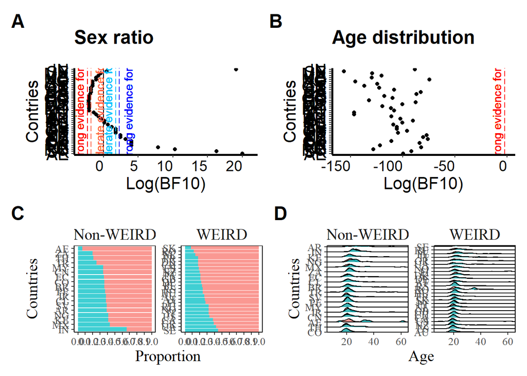

```r
BF_h3b_age <- data.frame(matrix(nrow = 0, ncol = 5))

colnames(BF_h3b_age) <- c("Observed", "Expected", "Log(BF10)", "BF10", "BF01")

# countries_names <- as.character(df_PSA001_valid_merge_sex_ratio_sored$Countries)
for (ii in seq(length(countries_order_sex))){
  country <- countries_order_sex[ii]
  if (country != "CN"){
    df_tmp <- df_PSA001_age_Jasp_filled_wide %>% dplyr::select('ageBins', one_of(country), "CN")
    BF_tmp <-  BayesMultiNomial(dataset = df_tmp,
                               factor = "ageBins", observed = country, expected = "CN")
    BF_h3b_age[ii,] <- c(country, "CN",BF_tmp$BF$LogBF10, BF_tmp$BF$BF10, BF_tmp$BF$BF01)
  }

}

BF_h3b_age_p <- BF_h3b_age %>%
  tidyr::drop_na() %>%
  dplyr::mutate(Contries = factor(Observed, levels = Observed),
                `Log(BF10)` = as.numeric(`Log(BF10)`))


p_BF_h3b_age_p <- ggplot(BF_h3b_age_p, aes( x = `Log(BF10)`, y = Contries )) +
  geom_point() +
  xlim(-160, 0) +
  scale_y_discrete(limits=rev) +
  geom_vline(xintercept = c(log(1/10)),
             colour = c("red"),
             linetype=c("longdash")) +
  geom_text(aes(x=log(1/10), label="Strong evidence for H0\n", y = 23), colour="red", alpha = 0.7,
            angle=90, text=element_text(size=10)) +
  ggtitle("Age distribution") +
  theme_bw() +
        theme(panel.grid.major = element_blank(),
         panel.grid.minor = element_blank(),
         panel.background = element_blank(),
         panel.border = element_blank(),
         text = element_text(family='Times'),
         # legend.title=element_blank(),
         legend.title = element_text(size =16),
         legend.text = element_text(size =14),
         axis.text.x = element_text (size = 14, color = 'black',  hjust = 1),
         axis.text.y = element_text (size = 16, color = 'black'),
         plot.title = element_text(lineheight=.8, face="bold", size = 18, margin=margin(0,0,20,0)),
         axis.text = element_text (size = 16, color = 'black'),
         axis.title = element_text (size = 16),
         axis.title.x = element_text (size = 16),
         # axis.title.y = element_blank(),
         axis.title.y = element_text( size = 16),
         axis.line.x = element_line(color='black', size = 1),
         axis.line.y = element_line(color='black', size = 1),
         strip.text = element_text (size = 16, color = 'black'),
         panel.spacing = unit(3, "lines")
        )

library(patchwork)
p_BF <- (p_BF_h3a_sex_p + p_BF_h3b_age_p) /
   (fig4a + fig4b) +
  plot_annotation( # title = 'Pairwise comparison between samples from China and other countries',
                  tag_levels = 'A')  &
  theme(plot.tag = element_text(size = 18, face = "bold"))

ggsave("Fig4_withBF.pdf", p_BF, device = "pdf", width=15, height = 20)
p_BF
```